# Which Language are You Going to Use as a noob Data Scientist?

## 4. Plotting the most popular tools

Let’s see how your favorite tools stack up against the rest.

```r
library(ggthemes)
```

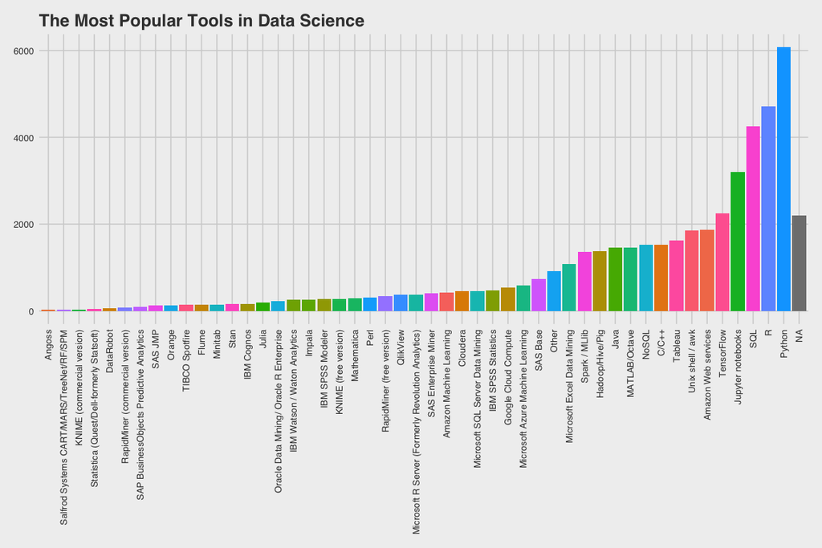

```r
# Creating a bar chart of the work_tools column.
# Arranging the bars so that the tallest are on the far right
ggplot(tool_count, aes(x = reorder(work_tools, count),
                       y = count)) +
    geom_bar(stat = "identity",
            aes(fill = work_tools)) +

# Adding non basic-cosmetic theme
  theme_fivethirtyeight() +

# Rotating the bar labels 90 degrees
    theme(axis.text.x = element_text(angle = 90,
                                    vjust = 0.5,
                                    hjust = 1)) +
    labs(title = "The Most Popular Tools in Data Science",
         x = "Tools",
         y = "Count") +
    theme(legend.position="none")
```

## 5. The R vs Python debate

Within the field of data science, there is a lot of debate among professionals about whether R or Python should reign supreme. You can see from our last figure that R and Python are the two most commonly used languages, but it’s possible that many respondents use both R and Python. Let’s take a look at how many people use R, Python, and both tools.

```r
# Creating a new data frame called debate_tools
debate_tools <- responses

# Creating a new column called language preference, based on the conditions specified in the Instructions
debate_tools <- debate_tools  %>%
   mutate(language_preference = case_when(
   grepl("R", WorkToolsSelect) & ! grepl("Python", WorkToolsSelect) ~ "R",
   ! grepl("R", WorkToolsSelect) & grepl("Python", WorkToolsSelect) ~ "Python",
   grepl("R", WorkToolsSelect) & grepl("Python", WorkToolsSelect) ~ "both",
   ! grepl("R", WorkToolsSelect) & ! grepl("Python", WorkToolsSelect) ~ "neither"))

# Printing the first 6 rows
head(debate_tools)
```

```
## # A tibble: 6 x 6
##   Respondent WorkToolsSelect LanguageRecomme… EmployerIndustry
##        <int> <chr>           <chr>            <chr>
## 1          1 Amazon Web ser… F#               Internet-based
## 2          2 Amazon Machine… Python           Mix of fields
## 3          3 C/C++,Jupyter … Python           Technology
## 4          4 Jupyter notebo… Python           Academic
## 5          5 C/C++,Cloudera… R                Government
## 6          6 SQL             Python           Non-profit
## # ... with 2 more variables: WorkAlgorithmsSelect <chr>,
## #   language_preference <chr>
```

## 6. Plotting R vs Python users

Now we just need to take a closer look at how many respondents use R, Python, and both!

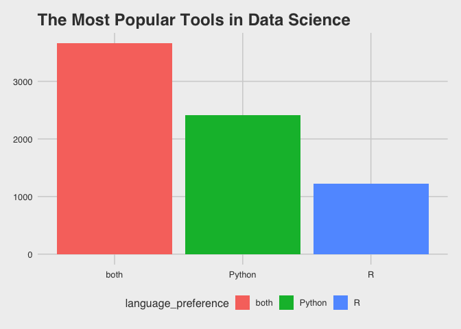

```r
# Creating a new data frame
debate_plot <- debate_tools

# Grouping by language preference and calculate number of responses
debate_plot <- debate_plot  %>%
   group_by(language_preference)  %>%
   summarise(count = n())  %>%

# Removing the row for users of "neither"
    filter(language_preference != "neither")

# Creating a bar chart
ggplot(debate_plot, aes(x = language_preference,
                        y = count)) +
    geom_bar(stat = "identity",
             aes(fill = language_preference)) +

  theme_fivethirtyeight() +

# Rotating the bar labels 90 degrees
    theme(axis.text.x = element_text(vjust = 0.5,
                                     hjust = 0.5)) +
    labs(title = "The Most Popular Tools in Data Science",
         x = "Tools", y = "Count")
```

## 7. Language recommendations

It looks like the largest group of professionals program in both Python and R. But what happens when they are asked which language they recommend to new learners? Do R lovers always recommend R?

```r
# Creating a new data frame
recommendations <- debate_tools

# Grouping by language_preference and then LanguageRecommendationSelect
recommendations <- recommendations  %>%
    group_by(language_preference, LanguageRecommendationSelect)  %>%
    summarise(count = n()) %>%

# Removing empty responses and include the top recommendations
    filter(LanguageRecommendationSelect != "NA") %>%
    arrange(language_preference, desc(count)) %>%
    mutate(row_no = row_number(language_preference)) %>%
    filter(row_no <= 4)

recommendations
```

```
## # A tibble: 16 x 4
## # Groups:   language_preference [4]
##    language_preference LanguageRecommendationSelect count row_no
##    <chr>               <chr>                        <int>  <int>
##  1 both                Python                        1917      1
##  2 both                R                              912      2
##  3 both                SQL                            108      3
##  4 both                Scala                           28      4
##  5 neither             Python                         196      1
##  6 neither             R                               94      2
##  7 neither             SQL                             53      3
##  8 neither             Matlab                          47      4
##  9 Python              Python                        1742      1
## 10 Python              C/C++/C#                        48      2
## 11 Python              Matlab                          43      3
## 12 Python              SQL                             36      4
## 13 R                   R                              632      1
## 14 R                   Python                         194      2
## 15 R                   SQL                             75      3
## 16 R                   C/C++/C#                        27      4
```

## 8. The most recommended language by the language used

Just one thing left. Let’s graphically determine which languages are most recommended based on the language that a person uses.

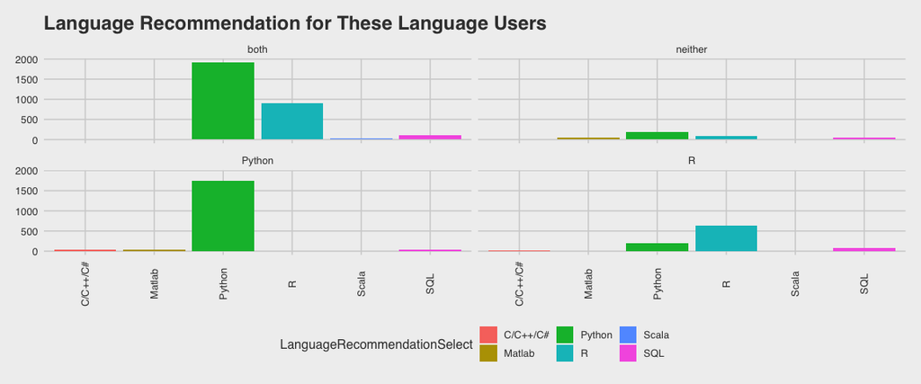

```r
# Creating a faceted bar plot
ggplot(recommendations, aes(x = LanguageRecommendationSelect,
                           y = count)) +
    geom_bar(stat = "identity",
            aes(fill = LanguageRecommendationSelect)) +
    facet_wrap(~ language_preference) +
  theme_fivethirtyeight() +
    theme(axis.text.x = element_text(angle = 90,
                                     vjust = 0.5,
                                     hjust = 0.5)) +
    labs(title = "Language Recommendation for These Language Users",
         x = "Tools", y = "Count")
```

## 9. The moral of the story

So we’ve made it to the end. We’ve found that Python is the most popular language used among Kaggle data scientists, but R users aren’t far behind. And while Python users may highly recommend that new learners learn Python, would R users find the following statement `TRUE` or `FALSE`?

```r
# Would R users find this statement TRUE or FALSE?
R_is_number_one = TRUE
```